# Lab 02 - Describe Data

2024-06-20

## 1 Load Data

### 1.1 Load DatasSet

```r
df <- read_delim("../../data/king-house-prices.csv.bz2")
```

### 1.1.2a Check rows and columns

```r
dim(df)
```

```
## [1] 21613    21
```

There are 21613 rows and 21 columns

### 1.1.2b Print few lines of data

```r
sample_n(df, 10)
```

```
## # A tibble: 10 × 21
##            id date         price bedrooms bathrooms sqft_living sqft_lot floors
##         <dbl> <date>       <dbl>    <dbl>     <dbl>       <dbl>    <dbl>  <dbl>
##  1   42000127 2015-02-24  406500        3      1.5         1970    10080    1
##  2 5648600010 2015-04-26  290000        3      2.5         1580     6860    2
##  3  103400160 2014-05-15  263000        3      2.25        1590     7748    2
##  4 7137900960 2014-06-25  235000        4      2           1570     9415    2
##  5 3629960600 2015-03-12  350000        3      1.75        1260     1111    2
##  6 1704900303 2014-12-11  608000        3      2.25        1720     5234    2
##  7 2450500060 2014-08-26 1620000        4      3.25        3820     8114    2
##  8 3905030330 2014-10-08  564800        3      2.25        1990     8501    2
##  9 2114700530 2015-01-22  360000        4      1           1460     3840    1.5
## 10 9269200831 2014-08-25  392000        3      1           1090     6125    1
## # ℹ 13 more variables: waterfront <lgl>, view <dbl>, condition <dbl>,
## #   grade <dbl>, sqft_above <dbl>, sqft_basement <dbl>, yr_built <dbl>,
## #   yr_renovated <dbl>, zipcode <dbl>, lat <dbl>, long <dbl>,
## #   sqft_living15 <dbl>, sqft_lot15 <dbl>
```

I’ve print 10 random rows as example. All these data looks good with correct data type and the values looks reasonable.

```r
colSums(is.na(df))
```

```
##            id          date         price      bedrooms     bathrooms
##             0             0             0             0             0
##   sqft_living      sqft_lot        floors    waterfront          view
##             0             0             0             0             0
##     condition         grade    sqft_above sqft_basement      yr_built
##             0             0             0             0             0
##  yr_renovated       zipcode           lat          long sqft_living15
##             0             0             0             0             0
##    sqft_lot15
##             0
```

There’s no null values in this dataset.

## 2. Listing price

### 2.1 Find max and min of listing price

```r
range(df$price)
```

```
## [1]   75000 7700000
```

The price of home range from 75,000 to 7,700,000. The price of housing was reasonable.

### 2.2 Compute mean and median

```r
df %>%
  summarise(mean = mean(price), median = median(price))
```

```
## # A tibble: 1 × 2
##      mean median
##     <dbl>  <dbl>
## 1 540088. 450000
```

### 2.3 compute standard deviation

```r
price <- df$price
sqrt(mean((price-mean(price))^2))
```

```
## [1] 367118.7
```

The standard deviation of price was $367118.7

### 2.4 compare sd calculation method

```r
sd(price)
```

```
## [1] 367127.2
```

the previous result is around $9 less than sd method. Since sd method uses 1/(N-1) instead of 1/N

### 2.5 plot price in linear scale and log scale

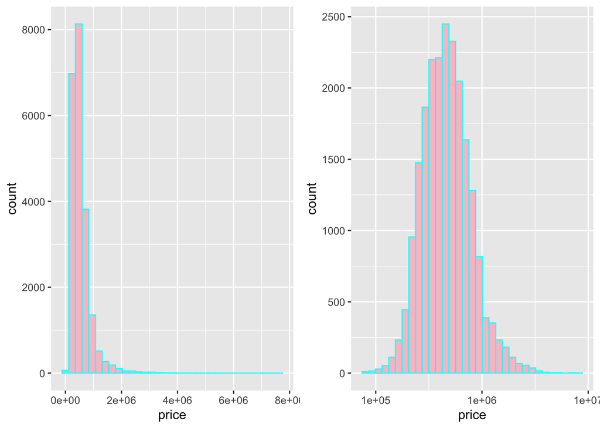

```r
l <- ggplot(df, aes(price)) +
  geom_histogram(bins = 33, fill = "pink", color="cyan")
s <- ggplot(df, aes(price)) +
  geom_histogram(bins = 33, fill = "pink", color="cyan") +
  scale_x_log10()
grid.arrange(l, s, ncol = 2)
```

### 2.6 Comment on histograms

For the linear scale graph on the left, the distribution is heavily right skewed with a really high tail at $8e+06. If we look at the log scale graph on the right, it shows us a normal distribution.

## 3. Sample proportions

### 3.1 Check percentage of cheap and expensive price

```r
df %>%
  summarize(cheap = mean(df$price < 200000), expensive = mean(df$price > 1000000))
```

```
## # A tibble: 1 × 2
##    cheap expensive
##    <dbl>     <dbl>
## 1 0.0364    0.0678
```

3.6% of the listing price are cheaper than $200,000 and 6.78% of the listing price are more expensive than $1M

### 3.2 Price less than 1M and overlook waterfront

```r
df %>%
  summarise(mean(price < 1000000 & waterfront))
```

```
## # A tibble: 1 × 1
##   `mean(price < 1e+06 & waterfront)`
##                                <dbl>
## 1                            0.00268
```

There are 0.268% of listing price that are less than $1M and overlooking waterfront

## 4 Condition and price

### 4.1 Median, mean, and sd of price in each of condition

```r
df %>%
  group_by(condition) %>%
  summarise(median = median(price), mean = mean(price), sd = sd(price))
```

```
## # A tibble: 5 × 4
##   condition median    mean      sd
##       <dbl>  <dbl>   <dbl>   <dbl>
## 1         1 262500 334432. 271173.
## 2         2 279000 327287. 245418.
## 3         3 450000 542013. 364449.
## 4         4 440000 521200. 358516.
## 5         5 526000 612418. 410972.
```

### 4.2 Make boxplot of relationship

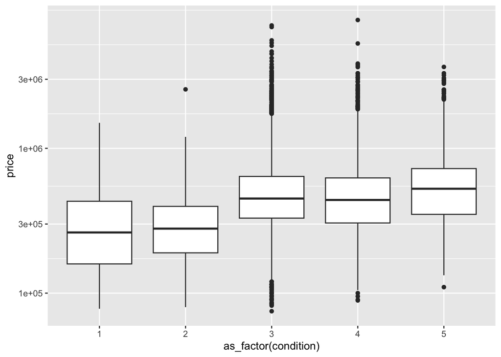

```r
ggplot(df, aes(as_factor(condition), price)) +
  geom_boxplot() +
  scale_y_log10()
```

### 4.3 Comment on lab

For aparment with 1 and 2 index of condition, there wasn’t much outlier. The graph demonstrate that the price tends to be higher for better condition apartment.